# NYPD Shooting Incidents Data Analysis

xxxx

5/19/2021

## 1. Background

The gun violence rate in NYC spiked in the 1980s and 1990s, and then dropped, and as of 2017, NYC is among the lowest of major cities in the US. However, similar to many other cities, NYC witnessed a surge in gun violence in 2020. This project is a very brief analysis of shooting incidents in NYC over the past 15 years based on a dataset at [DATA.GOV](https://www.data.gov/).

This dataset is a breakdown of every shooting incident that occurred in NYC going back to 2006 through the end of the previous calendar year. The data is manually extracted every quarter and reviewed by the Office of Management Analysis and Planning before being posted on the NYPD website. Each record represents a shooting incident in NYC and includes information about the event, the location, and time of occurrence. In addition, information related to suspect and victim demographics is also included. The data footnotes and additional information about this dataset can be found here: https://data.cityofnewyork.us/Public-Safety/NYPD-Shooting-Incident-Data-Historic-/833y-fsy8.

## 2. Data Preparation

### 2.1 Load the data

```r
library(tidyverse)
```

```r
# load NYPD shooting incidents data (historic) from https://www.data.gov
url <- "https://data.cityofnewyork.us/api/views/833y-fsy8/rows.csv?accessType=DOWNLOAD"
# data saved in a variable "shooting_raw"
shooting_raw <- read_csv(url)
```

### 2.2 A quick look of the dataset

First I take a quick look of the dataset to have a general idea about its structure.

```r
# A brief summary table
knitr::kable(summary(shooting_raw))
```

|  | INCIDENT_KEY | OCCUR_DATE | OCCUR_TIME | BORO | PRECINCT | JURISDICTION_CODE | LOCATION_DESC | STATISTICAL_MURDER_FLAG | PERP_AGE_GROUP | PERP_SEX | PERP_RACE | VIC_AGE_GROUP | VIC_SEX | VIC_RACE | X_COORD_CD | Y_COORD_CD | Latitude | Longitude | Lon_Lat |
| --- | --- | --- | --- | --- | --- | --- | --- | --- | --- | --- | --- | --- | --- | --- | --- | --- | --- | --- | --- |
|  | Min. : 9953245 | Length:23568 | Length:23568 | Length:23568 | Min. : 1.00 | Min. :0.0000 | Length:23568 | Mode :logical | Length:23568 | Length:23568 | Length:23568 | Length:23568 | Length:23568 | Length:23568 | Min. : 914928 | Min. :125757 | Min. :40.51 | Min. :-74.25 | Length:23568 |
|  | 1st Qu.: 55317014 | Class :character | Class1:hms | Class :character | 1st Qu.: 44.00 | 1st Qu.:0.0000 | Class :character | FALSE:19080 | Class :character | Class :character | Class :character | Class :character | Class :character | Class :character | 1st Qu.: 999900 | 1st Qu.:182565 | 1st Qu.:40.67 | 1st Qu.:-73.94 | Class :character |
|  | Median : 83365370 | Mode :character | Class2:difftime | Mode :character | Median : 69.00 | Median :0.0000 | Mode :character | TRUE :4488 | Mode :character | Mode :character | Mode :character | Mode :character | Mode :character | Mode :character | Median :1007645 | Median :193482 | Median :40.70 | Median :-73.92 | Mode :character |
|  | Mean :102218616 | NA | Mode :numeric | NA | Mean : 66.21 | Mean :0.3323 | NA | NA | NA | NA | NA | NA | NA | NA | Mean :1009363 | Mean :207312 | Mean :40.74 | Mean :-73.91 | NA |
|  | 3rd Qu.:150772442 | NA | NA | NA | 3rd Qu.: 81.00 | 3rd Qu.:0.0000 | NA | NA | NA | NA | NA | NA | NA | NA | 3rd Qu.:1016807 | 3rd Qu.:239163 | 3rd Qu.:40.82 | 3rd Qu.:-73.88 | NA |
|  | Max. :222473262 | NA | NA | NA | Max. :123.00 | Max. :2.0000 | NA | NA | NA | NA | NA | NA | NA | NA | Max. :1066815 | Max. :271128 | Max. :40.91 | Max. :-73.70 | NA |
|  | NA | NA | NA | NA | NA | NA’s :2 | NA | NA | NA | NA | NA | NA | NA | NA | NA | NA | NA | NA | NA |

```r
# To see the number of NA in this dataset
# I plan to remove the rows with missing data when I clean the data
sum(is.na(shooting_raw))
```

```
## [1] 38892
```

### 2.3 Data cleaning

```r
# Get rid of the columns not needed
shooting <- shooting_raw %>%
    select(-c(INCIDENT_KEY,OCCUR_TIME, PRECINCT, JURISDICTION_CODE,
              PERP_AGE_GROUP,PERP_SEX,LOCATION_DESC,STATISTICAL_MURDER_FLAG,
              VIC_AGE_GROUP,VIC_SEX,X_COORD_CD,Y_COORD_CD,Lon_Lat))

library(lubridate)
# Convert OCCUR_DATE to date type
shooting$OCCUR_DATE <-as.Date(shooting$OCCUR_DATE,format="%m/%d/%Y")

# Convert character columns to factors
shooting$BORO <- as.factor(shooting$BORO)
shooting$PERP_RACE<- as.factor(shooting$PERP_RACE)
shooting$VIC_RACE <- as.factor(shooting$VIC_RACE)

# Remove rows with missing data
# I assume the data is missing at random, so I remove any rows with missing data.
# Some potential bias will be discussed at the end of this report.
shooting <- na.omit(shooting)
# Check again to make sure there is no missing data
sum(is.na(shooting))
```

```
## [1] 0
```

```r
# Add another column "month_year" for future analysis
shooting <- shooting %>%
    mutate(year_month = format(OCCUR_DATE, format = "%Y-%m"))
```

### 2.4 A tidy table after data cleaning

```r
# A brief summary of the cleaned data
knitr::kable(summary(shooting), caption = "A summary of the NYPD shooting
             incidents data")
```

A summary of the NYPD shooting incidents data

|  | OCCUR_DATE | BORO | PERP_RACE | VIC_RACE | Latitude | Longitude | year_month |
| --- | --- | --- | --- | --- | --- | --- | --- |
|  | Min. :2006-01-01 | BRONX :4503 | AMERICAN INDIAN/ALASKAN NATIVE: 2 | AMERICAN INDIAN/ALASKAN NATIVE: 7 | Min. :40.52 | Min. :-74.23 | Length:15143 |
|  | 1st Qu.:2008-03-24 | BROOKLYN :5754 | ASIAN / PACIFIC ISLANDER : 120 | ASIAN / PACIFIC ISLANDER : 235 | 1st Qu.:40.67 | 1st Qu.:-73.94 | Class :character |
|  | Median :2010-07-04 | MANHATTAN :2000 | BLACK :9855 | BLACK :10348 | Median :40.70 | Median :-73.91 | Mode :character |
|  | Mean :2011-09-22 | QUEENS :2317 | BLACK HISPANIC :1081 | BLACK HISPANIC : 1492 | Mean :40.74 | Mean :-73.91 | NA |
|  | 3rd Qu.:2014-12-30 | STATEN ISLAND: 569 | UNKNOWN :1869 | UNKNOWN : 68 | 3rd Qu.:40.83 | 3rd Qu.:-73.88 | NA |
|  | Max. :2020-12-29 | NA | WHITE : 255 | WHITE : 478 | Max. :40.91 | Max. :-73.71 | NA |
|  | NA | NA | WHITE HISPANIC :1961 | WHITE HISPANIC : 2515 | NA | NA | NA |

```r
# Inspecting the first 10 rows
knitr::kable(head(shooting))
```

| OCCUR_DATE | BORO | PERP_RACE | VIC_RACE | Latitude | Longitude | year_month |
| --- | --- | --- | --- | --- | --- | --- |
| 2019-11-27 | BRONX | BLACK | BLACK | 40.81870 | -73.91857 | 2019-11 |
| 2019-02-02 | MANHATTAN | WHITE HISPANIC | BLACK HISPANIC | 40.79192 | -73.94548 | 2019-02 |
| 2019-10-24 | STATEN ISLAND | BLACK | BLACK | 40.63806 | -74.16611 | 2019-10 |
| 2019-08-22 | BRONX | BLACK HISPANIC | BLACK | 40.85455 | -73.91334 | 2019-08 |
| 2019-06-07 | BROOKLYN | WHITE HISPANIC | BLACK | 40.67983 | -73.90843 | 2019-06 |
| 2019-03-11 | BROOKLYN | BLACK | BLACK | 40.68757 | -73.93895 | 2019-03 |

## 3. Exploratory Data Analysis

Now I have a tidy table. With a few questions in mind, I perform a brief exploratory data analysis.

### 3.1 Where did the shootings take place?

To answer this question, I generate a dynamic map of shooting incidents in NYC based on the data from 2006 to 2020. The map can be zoomed and dragged to look at the number of shooting incidents in different locations.

```r
library(leaflet)
leaflet(shooting) %>%
    addTiles() %>% # draw a map based on OpenStreetMap tiles
    # add markers at the specified longitude and latitude
    addCircleMarkers(lat = shooting$Latitude, lng = shooting$Longitude,
                     clusterOptions = markerClusterOptions())
```

[interactive chart not shown]

### 3.2 Which borough in NYC has the most gun shootings?

I am interested to see whether certain borough has a higher number of shootings.

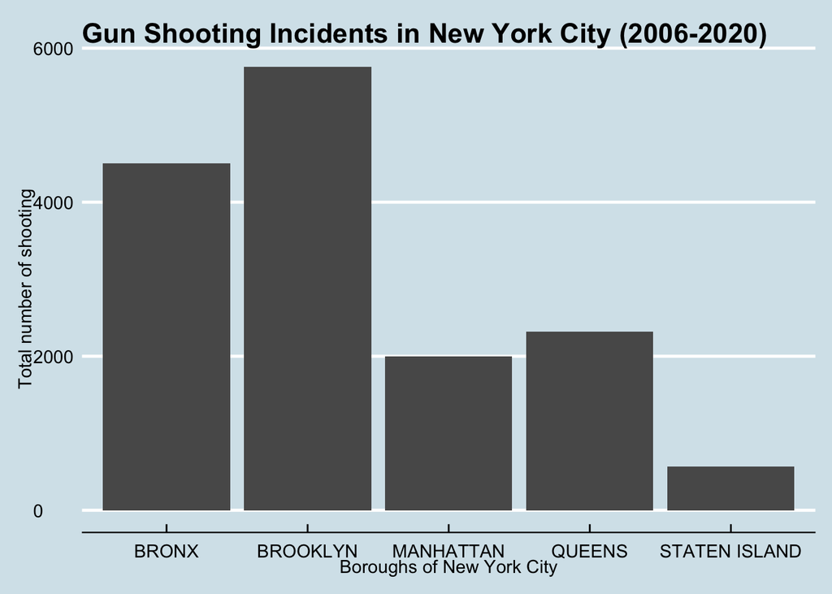

```r
library(ggplot2)
library(ggthemes)
shooting %>%
    ggplot(aes(BORO))+
    geom_bar()+
    xlab("Boroughs of New York City") +
    ylab("Total number of shooting") +
    ggtitle("Gun Shooting Incidents in New York City (2006-2020)") +
    theme_economist() # use the economist theme to pretty the figure
```

### 3.3 What is the racial distribution of perpetrators in each borough?

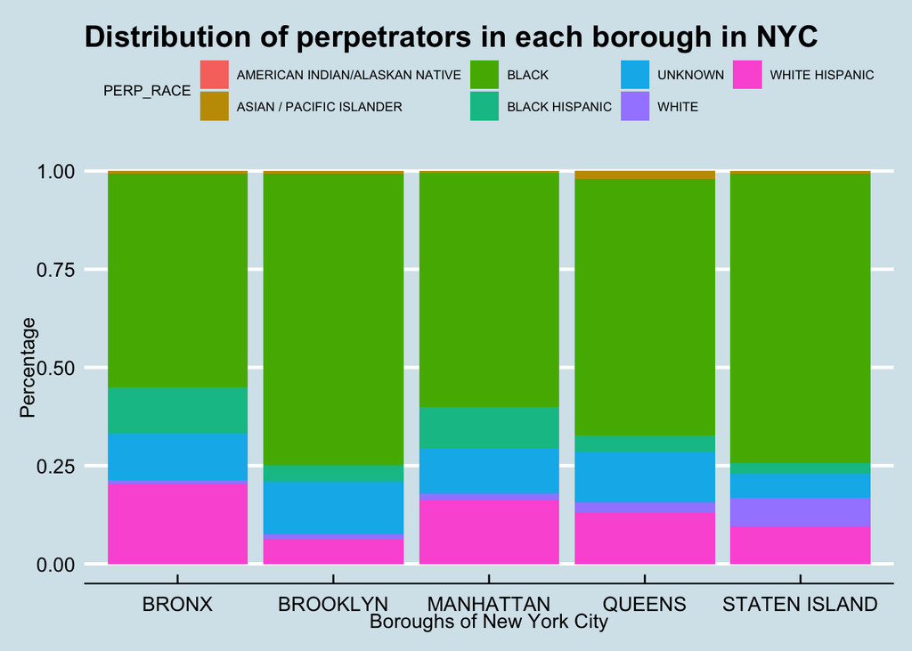

```r
shooting %>%
    ggplot(aes(BORO)) +
    geom_bar(mapping = aes(x=BORO,fill = PERP_RACE), position = "fill") +
    xlab("Boroughs of New York City") +
    ylab("Percentage") +
    ggtitle("Distribution of perpetrators in each borough in NYC") +
    theme_economist() +
    theme(legend.title = element_text(size = 8),legend.text = element_text(size = 7))
```

### 3.4 What is the racial distribution of victims in each borough?

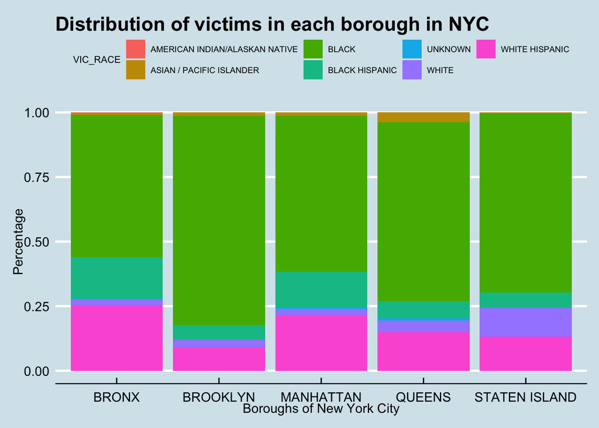

```r
shooting %>%
    ggplot(aes(BORO)) +
    geom_bar(mapping = aes(x = BORO,fill = VIC_RACE), position = "fill") +
    xlab("Boroughs of New York City") +
    ylab("Percentage") +
    ggtitle("Distribution of victims in each borough in NYC") +
    theme_economist() +
    theme(legend.title = element_text(size = 8),legend.text=element_text(size = 7))
```

### 3.5 Is the number of shootings dropped over the past 15 years?

```r
month_count <- shooting %>%
    group_by(year_month) %>% # group by year and by month
    summarise(count = n()) # count the number of observations in each month
month_count
```

```
## # A tibble: 180 x 2
##    year_month count
##    <chr>      <int>
##  1 2006-01      127
##  2 2006-02       96
##  3 2006-03      102
##  4 2006-04      156
##  5 2006-05      170
##  6 2006-06      164
##  7 2006-07      226
##  8 2006-08      239
##  9 2006-09      187
## 10 2006-10      172
## # … with 170 more rows
```

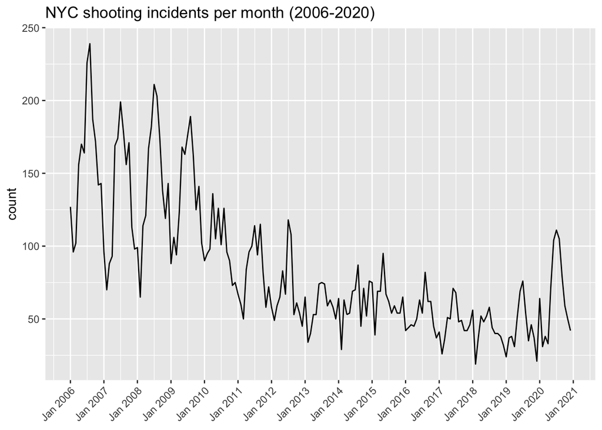

```r
month_count <-as.data.frame(month_count)
month_count$year_month2 <-as.Date(paste(month_count$year_month,"01",sep = "-","%Y-%m-%d"))
ggplot(month_count,aes(x = year_month2,y = count))+
    geom_line() +
    ggtitle("NYC shooting incidents per month (2006-2020)") +
    scale_x_date(NULL,date_labels = "%b %Y",breaks = "year") +
    theme(axis.text.x = element_text(angle = 45,hjust = 1,vjust = 1))
```

Generally, the number of shootings in NYC has been dramatically decreased since 2006. However, the shootings surged in 2020 to levels not seen in years. Additionally, the number of shootings has a seasonal pattern, with more during the summer and fewer during the winter.

### 3.6 Can we predict the number of shootings in NYC in 2021?

#### 3.6.1 A predictive model based on the Holter-Winters’ method

I chose the Holt-Winters model, which could model three aspects of the time series: average (the typical value), trend (the slope over time), and seasonality (the cyclical repeating pattern). This model uses exponential smoothing to encode data from the past and use them to predict “typical” values for the present and future.

```r
library(forecast)
# I use the data since 2011 to train the model
series <- ts(month_count[61:180,2],frequency = 12)
shooting_model <- HoltWinters(series,seasonal = "multi")
shooting_model
```

```
## Holt-Winters exponential smoothing with trend and multiplicative seasonal component.
##
## Call:
## HoltWinters(x = series, seasonal = "multi")
##
## Smoothing parameters:
##  alpha: 0.2252392
##  beta : 0.02908243
##  gamma: 0.2926619
##
## Coefficients:
##           [,1]
## a   62.3869868
## b    0.2585618
## s1   1.0459088
## s2   0.6679825
## s3   0.8585208
## s4   0.8979814
## s5   1.2510536
## s6   1.4783204
## s7   1.5004351
## s8   1.2796380
## s9   1.0241585
## s10  0.9966619
## s11  0.8627991
## s12  0.7796838
```

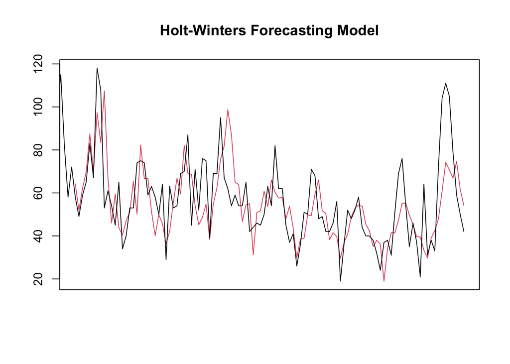

```r
plot(shooting_model,ann = F,xaxt = "n")
title("Holt-Winters Forecasting Model")
```

#### 3.6.2 Forecasting of shooting numbers in NYC in 2021

```r
# predict the number of shootings in each month of 2021
shooting_2021 <-forecast(shooting_model,h=12)
shooting_2021
```

```
##        Point Forecast    Lo 80     Hi 80     Lo 95     Hi 95
## Jan 11       65.52153 56.59731  74.44576 51.873108  79.16996
## Feb 11       42.01885 32.62815  51.40954 27.657015  56.38068
## Mar 11       54.22647 42.86154  65.59140 36.845307  71.60764
## Apr 11       56.95109 44.30938  69.59280 37.617262  76.28492
## May 11       79.66684 62.79686  96.53682 53.866426 105.46725
## Jun 11       94.52138 74.25341 114.78934 63.524203 125.51855
## Jul 11       96.32331 74.85933 117.78729 63.496982 129.14964
## Aug 11       82.47968 62.81658 102.14279 52.407558 112.55181
## Sep 11       66.27743 48.96099  83.59388 39.794214  92.76066
## Oct 11       64.75572 46.90598  82.60546 37.456894  92.05454
## Nov 11       56.28139 39.44664  73.11615 30.534861  82.02793
## Dec 11       51.06128 20.79683  81.32573  4.775792  97.34677
```

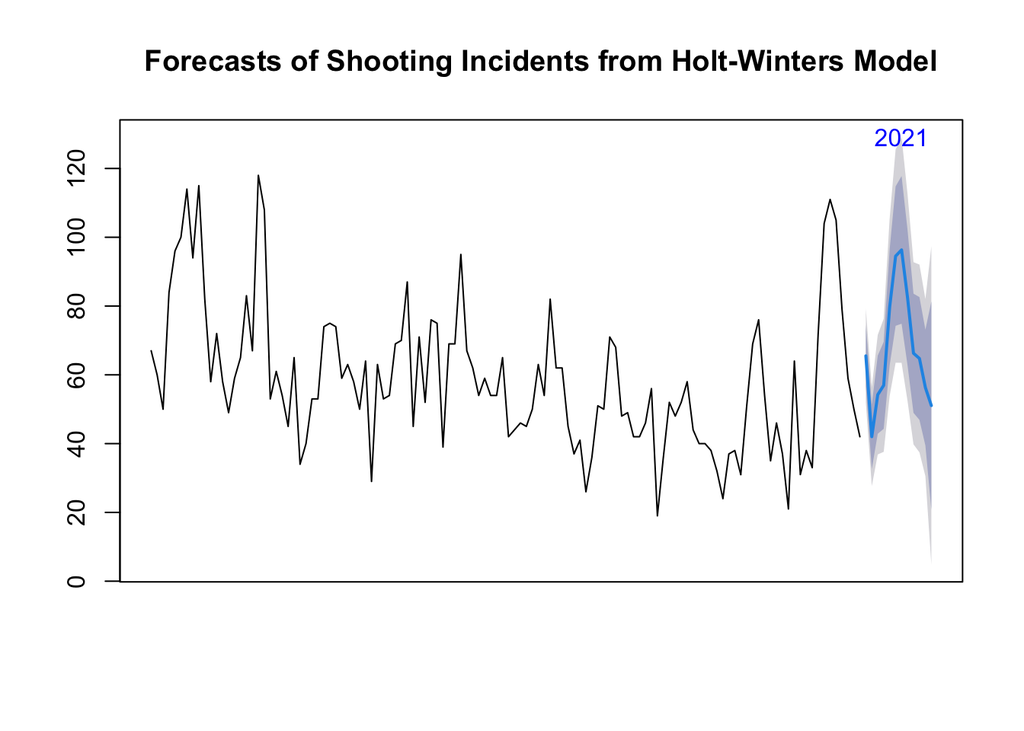

```r
plot(shooting_2021,ann = F,xaxt = "n")
title("Forecasts of Shooting Incidents from Holt-Winters Model")
text(11.5,129,"2021",col = "blue") # add a label "2021" to highlight the prediction
```

## 4. Conclusions

- The gun shooting incidents are not evenly distributed across NYC. The Brooklyn and Staten island boroughs have the highest and lowest number of shooting incidents, respectively, over the past 15 years.
- The analysis indicates a significantly higher number of shootings for African Americans (both perpetrators and victims) than that of other ethnic groups.
- In general, the number of shootings in NYC has been dramatically decreased since 2006, except last year the shootings surged to levels not seen in years. Additionally, there is a clear seasonal pattern, with more observations in the summer and fewer in the winter.
- A predictive model was created to predict the number of shootings in 2021, and it would be interesting to compare with the real data when they become fully available. Other factors could be included for further analysis, such as the COVID pandemic, increased unemployment rate, and reduced police enforcement.

## 5. Potential Bias

- According to the data footnote, only shooting incidents resulting in an injured victim were included in the dataset. This may underestimate the severity of gun violence in NYC.
- As stated in the background session, the data is manually extracted every quarter and reviewed by the Office of Management Analysis and Planning before being posted on the NYPD website. If the person reviewing the data had some personal bias, it could skew the dataset.
- My personal bias might be that I assume the missing data occurred randomly and it would not interfere with my analysis if the missing data were removed. The results of my analysis turned out to be very similar to what I would expect personally, which further confirmed my assumption. However, I reminded myself to be very careful and I actually reran my data analysis without removing the missing data. Fortunately, the conclusions generally remained valid, probably because my analysis was very simple and exploratory. If a deeper analysis was performed, omitting the observations with missing data could lead to analysis pitfalls and cause inaccurate conclusions.

## 6. Reference

- Crime in New York City https://en.wikipedia.org/wiki/Crime_in_New_York_City